# Text Using Markdown

**If you double click on this cell**, you will see the text change so that all of the formatting is removed. This allows you to edit this block of text. This block of text is written using [Markdown](http://daringfireball.net/projects/markdown/syntax), which is a way to format text using headers, links, italics, and many other options. Hit *shift* + *enter* or *shift* + *return* on your keyboard to show the formatted text again. This is called "running" the cell, and you can also do it using the run button in the toolbar.

# Code cells

One great advantage of IPython notebooks is that you can show your Python code alongside the results, add comments to the code, or even add blocks of text using Markdown. These notebooks allow you to collaborate with others and share your work. The following cell is a code cell.

```python
# Hit shift + enter or use the run button to run this cell and see the results

print ('hello world')
```

```
hello world
```

```python
# The last line of every code cell will be displayed by default,
# even if you don't print it. Run this cell to see how this works.

2 + 2 # The result of this line will not be displayed
3 + 3 # The result of this line will be displayed, because it is the last line of the cell
```

```
6
```

# Nicely formatted results

IPython notebooks allow you to display nicely formatted results, such as plots and tables, directly in the notebook. You'll learn how to use the following libraries later on in this course, but for now here's a preview of what IPython notebook can do.

```python
# If you run this cell, you should see the values displayed as a table.

# Pandas is a software library for data manipulation and analysis. You'll learn to use it later in this course.
import pandas as pd

df = pd.DataFrame({'a': [2, 4, 6, 8], 'b': [1, 3, 5, 7]})
df
```

|  | a | b |
| --- | --- | --- |
| 0 | 2 | 1 |
| 1 | 4 | 3 |
| 2 | 6 | 5 |
| 3 | 8 | 7 |

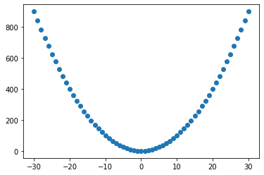

```python
# If you run this cell, you should see a scatter plot of the function y = x^2

%pylab inline
import matplotlib.pyplot as plt

xs = range(-30, 31)
ys = [x ** 2 for x in xs]

plt.scatter(xs, ys)
```

teste

# Creating cells

To create a new **code cell**, click "Insert > Insert Cell [Above or Below]". A code cell will automatically be created.

To create a new **markdown cell**, first follow the process above to create a code cell, then change the type from "Code" to "Markdown" using the dropdown next to the run, stop, and restart buttons.

# Re-running cells

```python
class_name = "Rafael"
```

```python
message = class_name + " is awesome!"
```

```python
message
```

```
'Rafael is awesome!'
```

You should have seen the output change to "*your name* is awesome!" Often, after changing a cell, you'll want to rerun all the cells below it. You can do that quickly by clicking "Cell > Run All Below".

One final thing to remember: if you shut down the kernel after saving your notebook, the cells' output will still show up as you left it at the end of your session when you start the notebook back up. However, the state of the kernel will be reset. If you are actively working on a notebook, remember to re-run your cells to set up your working environment to really pick up where you last left off.